# Lab: R Plotting with ggplot2

Xuemao Zhang

June 25, 2019

## Introduction

- All [ggplot2](https://ggplot2.tidyverse.org/reference/) plots begin with a call to `ggplot()`, supplying default data and aesthethic mappings, specified by `aes()`. To save a plot to disk, use `ggsave()`. For function references, please see https://ggplot2.tidyverse.org/reference/.
- Install the following packages if you don’t have them.

```
                install.packages('ggplot2');
                install.packages('gridExtra');
```

- In this session, we analyze the Housing prices data (https://github.com/IQSS/workshops/blob/master/R/Rgraphics/dataSets/landdata-states.csv) data from a Harvard University github: Institute for Quantitative Social Science (https://github.com/IQSS).
- The data can be read from the web directly:

```r
url="https://raw.githubusercontent.com/IQSS/workshops/master/R/Rgraphics/dataSets/landdata-states.csv";
housing = read.csv(url, stringsAsFactors = FALSE);
```

- If you already downloaded the data, import from your local disk:

```r
housing = read.csv("F:/DataCamp/data/landdata-states.csv",header=TRUE, sep=",");
dim(housing);
```

```
## [1] 7803   11
```

```r
str(housing);
```

```
## 'data.frame':    7803 obs. of  11 variables:
##  $ State           : Factor w/ 51 levels "AK","AL","AR",..: 1 1 1 1 1 1 1 1 1 1 ...
##  $ region          : Factor w/ 4 levels "Midwest","N. East",..: 4 4 4 4 4 4 4 4 4 4 ...
##  $ Date            : num  2010 2010 2010 2010 2008 ...
##  $ Home.Value      : int  224952 225511 225820 224994 234590 233714 232999 232164 231039 229395 ...
##  $ Structure.Cost  : int  160599 160252 163791 161787 155400 157458 160092 162704 164739 165424 ...
##  $ Land.Value      : int  64352 65259 62029 63207 79190 76256 72906 69460 66299 63971 ...
##  $ Land.Share..Pct.: num  28.6 28.9 27.5 28.1 33.8 32.6 31.3 29.9 28.7 27.9 ...
##  $ Home.Price.Index: num  1.48 1.48 1.49 1.48 1.54 ...
##  $ Land.Price.Index: num  1.55 1.58 1.49 1.52 1.88 ...
##  $ Year            : int  2010 2010 2009 2009 2007 2008 2008 2008 2008 2009 ...
##  $ Qrtr            : int  1 2 3 4 4 1 2 3 4 1 ...
```

## Some data manipulations

- First, check if there are missing values

```r
which(complete.cases(housing) == F);
```

```
##   [1] 7651 7652 7653 7654 7655 7656 7657 7658 7659 7660 7661 7662 7663 7664
##  [15] 7665 7666 7667 7668 7669 7670 7671 7672 7673 7674 7675 7676 7677 7678
##  [29] 7679 7680 7681 7682 7683 7684 7685 7686 7687 7688 7689 7690 7691 7692
##  [43] 7693 7694 7695 7696 7697 7698 7699 7700 7701 7702 7703 7704 7705 7706
##  [57] 7707 7708 7709 7710 7711 7712 7713 7714 7715 7716 7717 7718 7719 7720
##  [71] 7721 7722 7723 7724 7725 7726 7727 7728 7729 7730 7731 7732 7733 7734
##  [85] 7735 7736 7737 7738 7739 7740 7741 7742 7743 7744 7745 7746 7747 7748
##  [99] 7749 7750 7751 7752 7753 7754 7755 7756 7757 7758 7759 7760 7761 7762
## [113] 7763 7764 7765 7766 7767 7768 7769 7770 7771 7772 7773 7774 7775 7776
## [127] 7777 7778 7779 7780 7781 7782 7783 7784 7785 7786 7787 7788 7789 7790
## [141] 7791 7792 7793 7794 7795 7796 7797 7798 7799 7800 7801 7802 7803
```

```r
housing_missing= subset(housing, complete.cases(housing) == F);
head(housing_missing);
```

```
##      State region    Date Home.Value Structure.Cost Land.Value
## 7651    DC   <NA> 2003.00     384443          93922     290522
## 7652    DC   <NA> 2003.25     399633          93961     305673
## 7653    DC   <NA> 2003.50     417110          94032     323078
## 7654    DC   <NA> 2003.75     436496          94486     342010
## 7655    DC   <NA> 2004.00     457806          95807     361999
## 7656    DC   <NA> 2004.25     481171          98379     382792
##      Land.Share..Pct. Home.Price.Index Land.Price.Index Year Qrtr
## 7651             75.6            1.469            1.654 2002    4
## 7652             76.5            1.527            1.740 2003    1
## 7653             77.5            1.594            1.839 2003    2
## 7654             78.4            1.668            1.947 2003    3
## 7655             79.1            1.749            2.062 2003    4
## 7656             79.6            1.839            2.182 2004    1
```

```r
tail(housing_missing);
```

```
##      State region    Date Home.Value Structure.Cost Land.Value
## 7798    DC   <NA> 2009.50     630361         148268     482092
## 7799    DC   <NA> 2009.75     632103         148074     484029
## 7800    DC   <NA> 2012.00     676463         165456     511007
## 7801    DC   <NA> 2012.25     690234         166701     523532
## 7802    DC   <NA> 2012.50     705645         167978     537666
## 7803    DC   <NA> 2012.75     722514         169289     553225
##      Land.Share..Pct. Home.Price.Index Land.Price.Index Year Qrtr
## 7798             76.5            2.409            2.802 2009    2
## 7799             76.6            2.415            2.817 2009    3
## 7800             75.5            2.585            3.025 2011    4
## 7801             75.8            2.637            3.107 2012    1
## 7802             76.2            2.696            3.198 2012    2
## 7803             76.6            2.761            3.299 2012    3
```

- It can be seen that the region is missing for `DC` state

```r
unique(housing$region); #Unique values of the 'region' variable
```

```
## [1] West    South   N. East Midwest <NA>
## Levels: Midwest N. East South West
```

- Let’s put DC to the “South” region

```r
housing$region=as.character(housing$region); #Change the region  variable to character
housing$region=ifelse(is.na(housing$region), 'South', housing$region);
housing$region=as.factor(housing$region); #change it back to factor
levels(housing$region);
```

```
## [1] "Midwest" "N. East" "South"   "West"
```

```r
which(complete.cases(housing) == F);
```

```
## integer(0)
```

```r
summary(housing);
```

```
##      State          region          Date        Home.Value
##  AK     : 153   Midwest:1836   Min.   :1975   Min.   : 18763
##  AL     : 153   N. East:1377   1st Qu.:1985   1st Qu.: 62235
##  AR     : 153   South  :2601   Median :1994   Median :108724
##  AZ     : 153   West   :1989   Mean   :1994   Mean   :135313
##  CA     : 153                  3rd Qu.:2004   3rd Qu.:172031
##  CO     : 153                  Max.   :2013   Max.   :862885
##  (Other):6885
##  Structure.Cost     Land.Value     Land.Share..Pct. Home.Price.Index
##  Min.   : 17825   Min.   :   938   Min.   : 5.00    Min.   :0.1350
##  1st Qu.: 53777   1st Qu.:  4178   1st Qu.: 5.00    1st Qu.:0.4550
##  Median : 88352   Median :  9478   Median :10.40    Median :0.7830
##  Mean   : 99534   Mean   : 35779   Mean   :18.17    Mean   :0.8695
##  3rd Qu.:134871   3rd Qu.: 38631   3rd Qu.:26.30    3rd Qu.:1.2075
##  Max.   :325595   Max.   :594417   Max.   :81.70    Max.   :2.8930
##
##  Land.Price.Index       Year           Qrtr
##  Min.   : 0.0000   Min.   :1975   Min.   :1.00
##  1st Qu.: 0.0020   1st Qu.:1984   1st Qu.:1.00
##  Median : 0.2520   Median :1994   Median :2.00
##  Mean   : 0.9912   Mean   :1994   Mean   :2.49
##  3rd Qu.: 1.1510   3rd Qu.:2003   3rd Qu.:3.00
##  Max.   :15.4340   Max.   :2013   Max.   :4.00
##
```

## Graphs

### Histograms

- Histogram of `Home.Value`

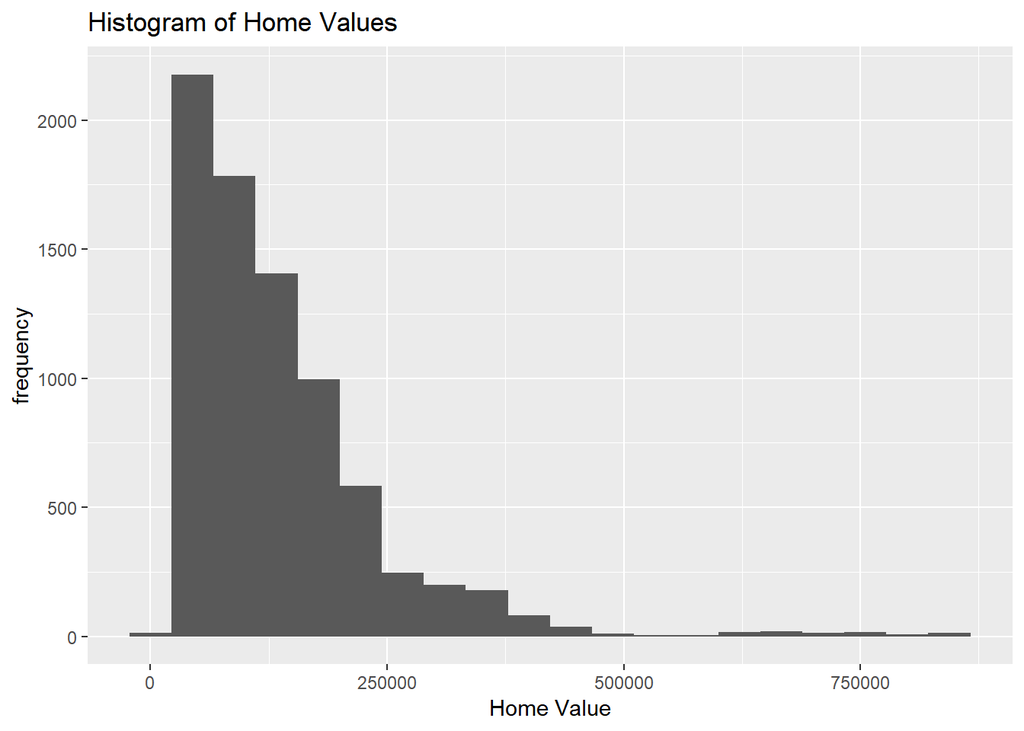

```r
library(ggplot2)
hist1=ggplot(housing, aes(x = Home.Value)) +
  geom_histogram(bins=20)+
  ggtitle("Histogram of Home Values")+
  xlab("Home Value") + ylab("frequency");
print(hist1);
```

- Histogram of `Home.Value` by `region`.

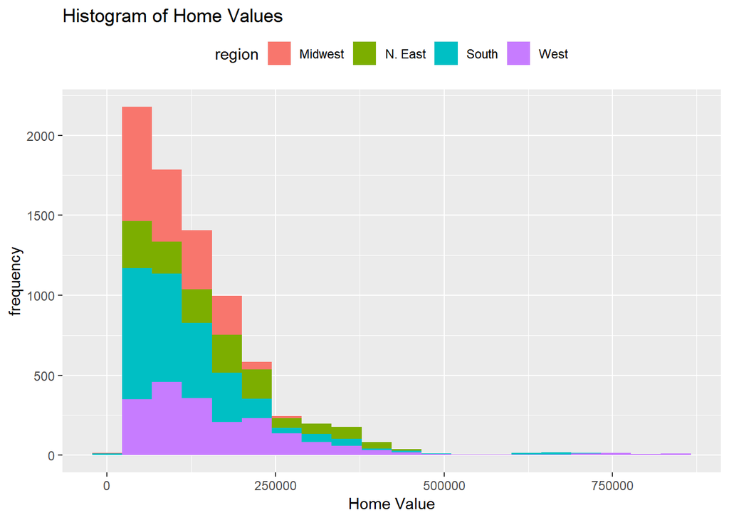

```r
hist2=ggplot(housing, aes(x = Home.Value)) +
  geom_histogram(aes(fill = region),bins=20)+
  ggtitle("Histogram of Home Values")+
  xlab("Home Value") + ylab("frequency")+
  theme(legend.position="top");
print(hist2);
```

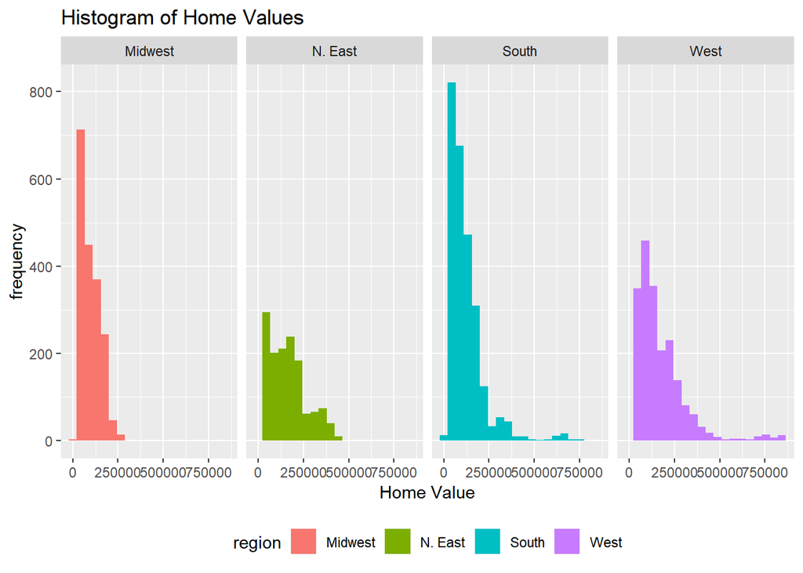

```r
hist3=ggplot(housing, aes(x = Home.Value)) +
  geom_histogram(aes(fill = region),bins=20)+
  ggtitle("Histogram of Home Values")+
  xlab("Home Value") + ylab("frequency")+
  facet_grid(~region)+
  theme(legend.position="bottom");
print(hist3);
```

### Scatter plots

- Let’s see the relationship between `Home.Value` and `Land.Value`

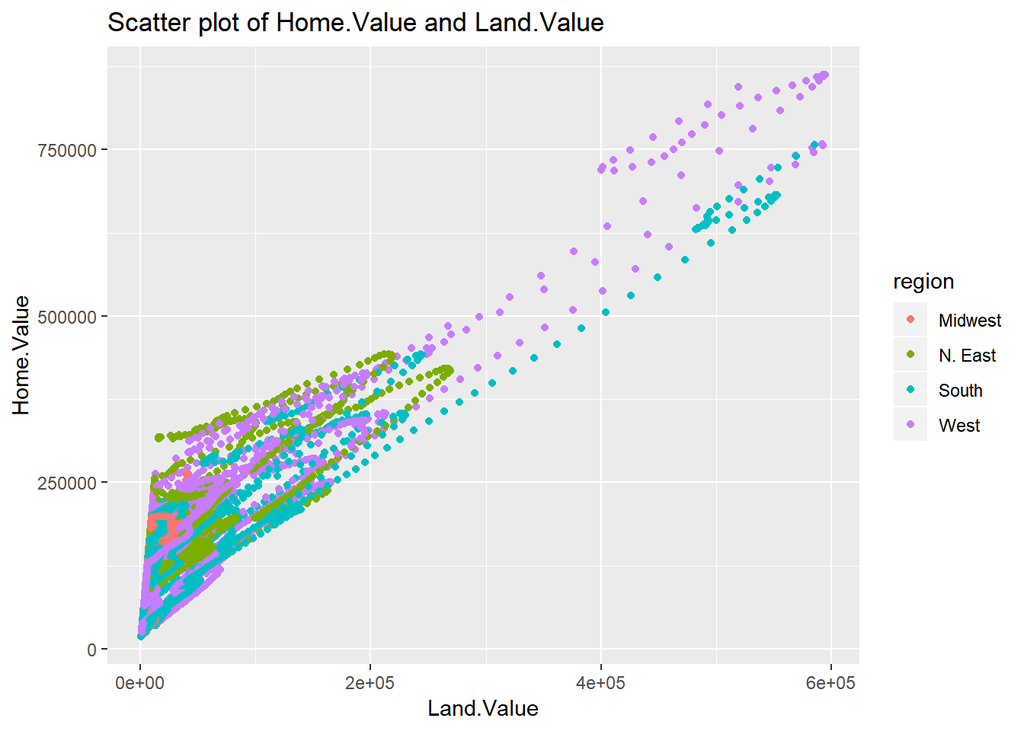

```r
ggplot(housing, aes(x=Land.Value, y=Home.Value, color=region)) +
geom_point()+
ggtitle("Scatter plot of Home.Value and Land.Value");
```

- Consider the sub data set for the year 2010.

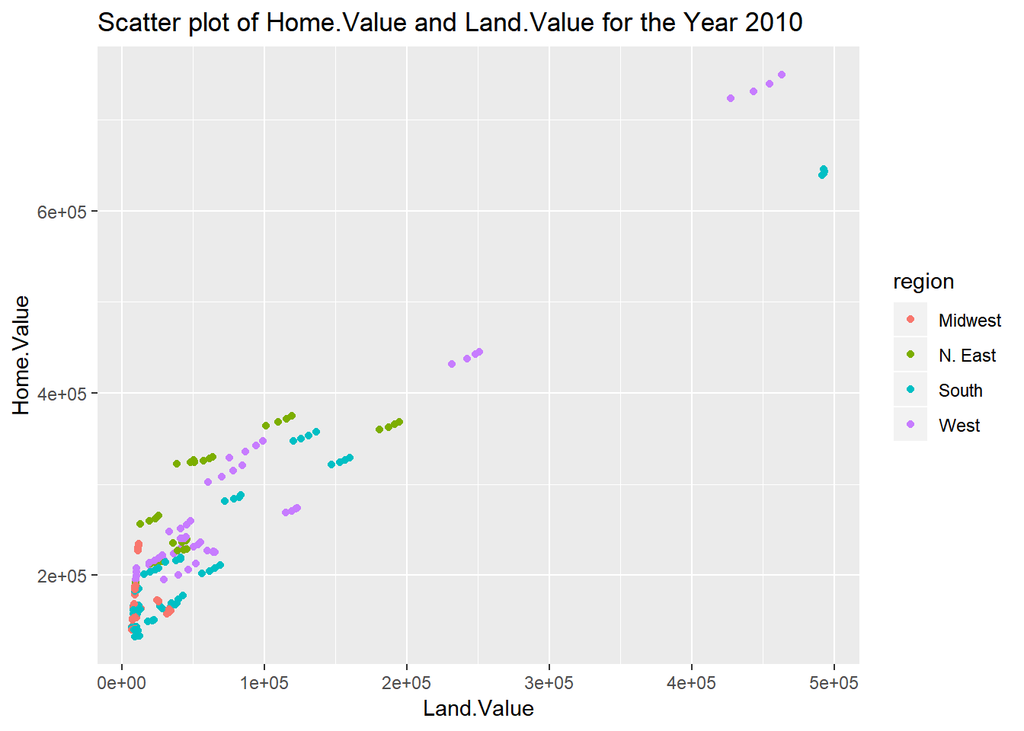

```r
housing2010=subset(housing, housing$Year==2010);
ggplot(housing2010, aes(x=Land.Value, y=Home.Value, color=region)) +
geom_point()+
ggtitle("Scatter plot of Home.Value and Land.Value for the Year 2010");
```

- Consider the log transformation for both variables.

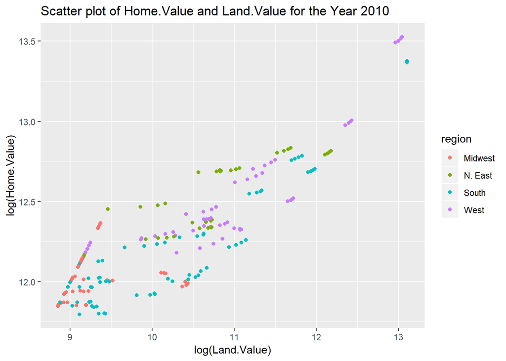

```r
ggplot(housing2010, aes(x=log(Land.Value), y=log(Home.Value), color=region)) +
geom_point()+
ggtitle("Scatter plot of Home.Value and Land.Value for the Year 2010");
```

- Add another Aesthetic - size by `Land.Price.Index`

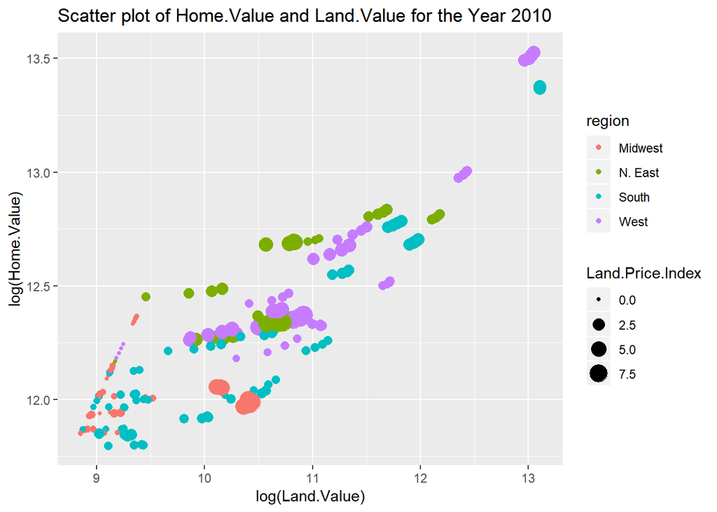

```r
ggplot(housing2010, aes(x=log(Land.Value), y=log(Home.Value), color=region)) +
geom_point(aes(size=Land.Price.Index))+
ggtitle("Scatter plot of Home.Value and Land.Value for the Year 2010");
```

- Add a smoother - a (regression) curve indicating the patter between the two variables

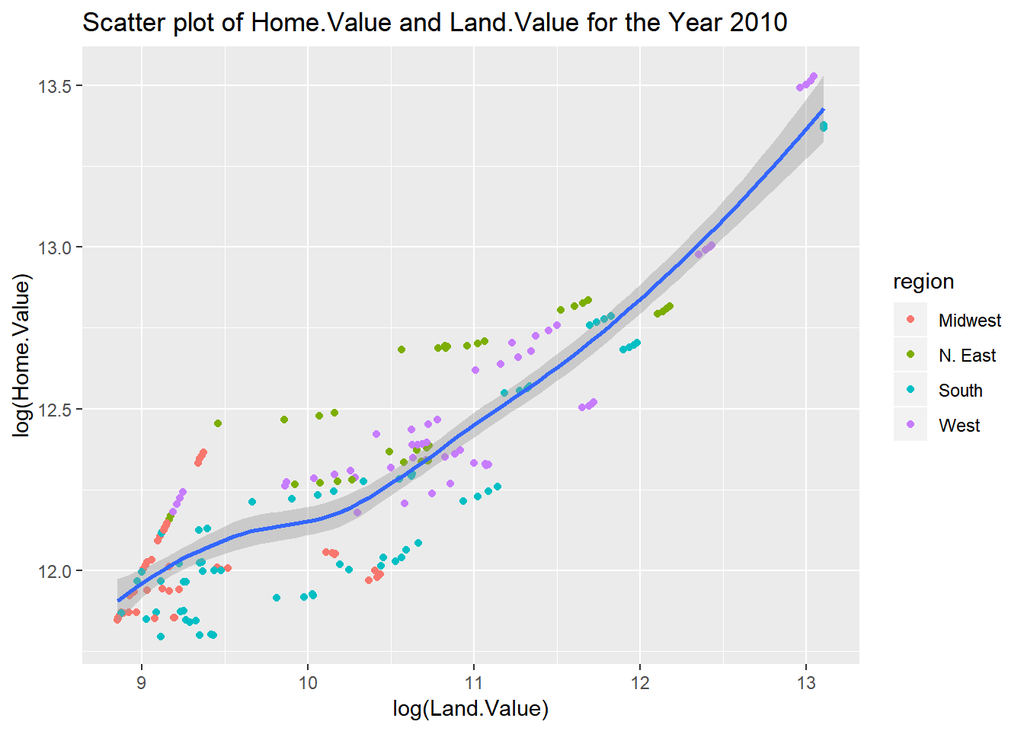

```r
ggplot(housing2010, aes(x=log(Land.Value), y=log(Home.Value))) +
geom_point(aes(color=region))+
ggtitle("Scatter plot of Home.Value and Land.Value for the Year 2010")+
geom_smooth();
```

### Time series plot

- To see the trend of the house prices over the year, we consider average values of the variable `Home.Value` by `State` and `Year`

```r
housing$Year=as.factor(housing$Year);
housing_mean1=aggregate(Home.Value~ State+Year, data = housing, FUN= "mean");
str(housing_mean1);
```

```
## 'data.frame':    1989 obs. of  3 variables:
##  $ State     : Factor w/ 51 levels "AK","AL","AR",..: 1 2 3 4 5 6 7 8 9 10 ...
##  $ Year      : Factor w/ 39 levels "1975","1976",..: 1 1 1 1 1 1 1 1 1 1 ...
##  $ Home.Value: num  56891 25185 20437 33523 43676 ...
```

```r
housing_mean1$Year=as.integer(as.character(housing_mean1$Year));
str(housing_mean1);
```

```
## 'data.frame':    1989 obs. of  3 variables:
##  $ State     : Factor w/ 51 levels "AK","AL","AR",..: 1 2 3 4 5 6 7 8 9 10 ...
##  $ Year      : int  1975 1975 1975 1975 1975 1975 1975 1975 1975 1975 ...
##  $ Home.Value: num  56891 25185 20437 33523 43676 ...
```

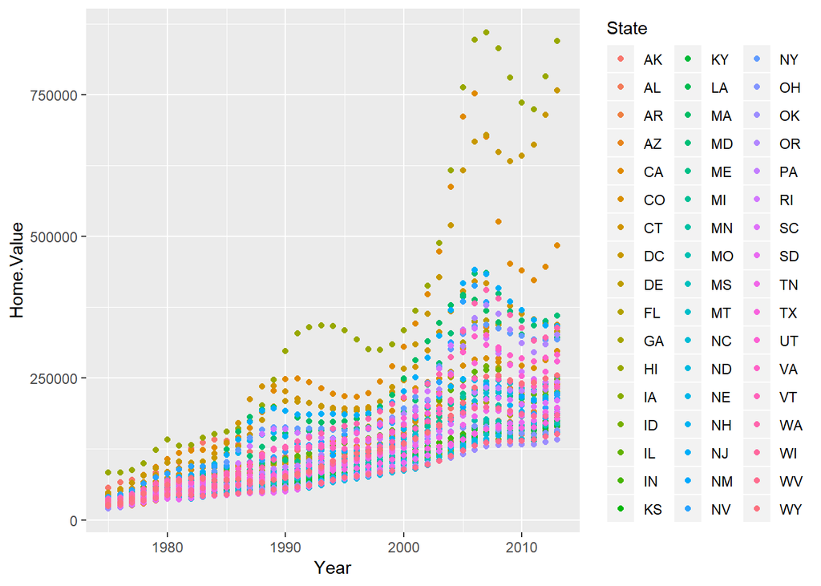

```r
ggplot(housing_mean1, aes(x=Year, y=Home.Value))+
  geom_point(aes(color=State));
```

- Or we can collapse the variable `Home.Value` by `region` and `Year`.

```r
housing$Year=as.factor(housing$Year);
housing_mean2=aggregate(Home.Value~ region+Year, data = housing, FUN= "mean");
housing_mean2$Year=as.integer(as.character(housing_mean2$Year));
str(housing_mean2);
```

```
## 'data.frame':    156 obs. of  3 variables:
##  $ region    : Factor w/ 4 levels "Midwest","N. East",..: 1 2 3 4 1 2 3 4 1 2 ...
##  $ Year      : int  1975 1975 1975 1975 1976 1976 1976 1976 1977 1977 ...
##  $ Home.Value: num  28008 33273 28954 38717 30375 ...
```

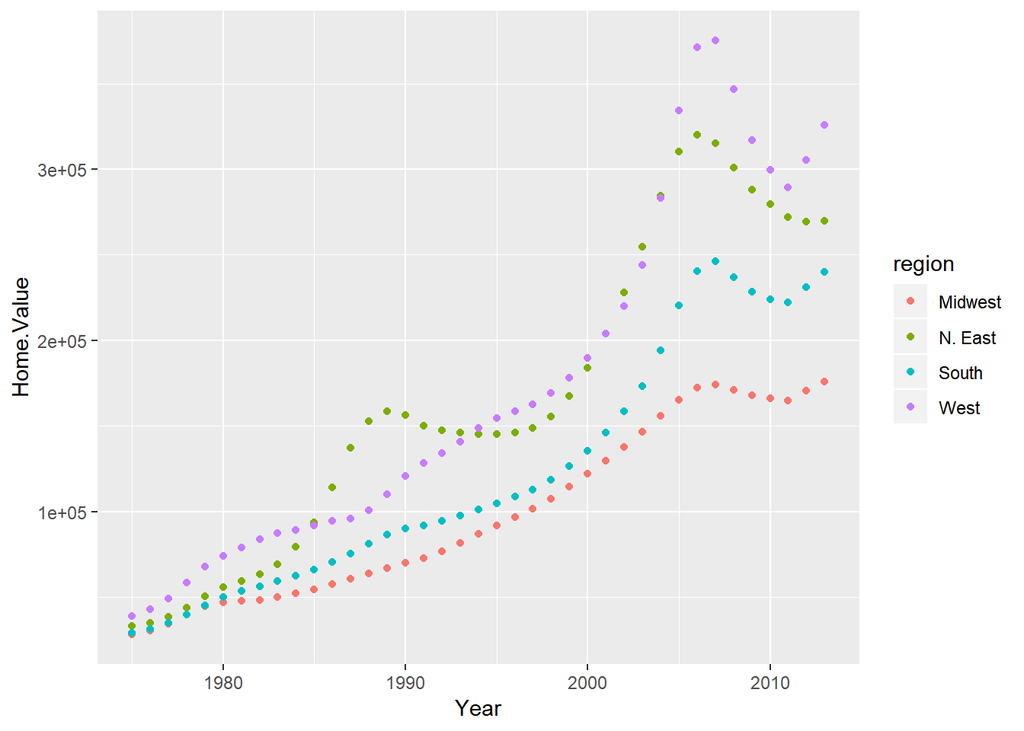

```r
ggplot(housing_mean2, aes(x=Year, y=Home.Value))+
  geom_point(aes(color=region));
```

### Faceting

- What is the trend in housing prices in each state?

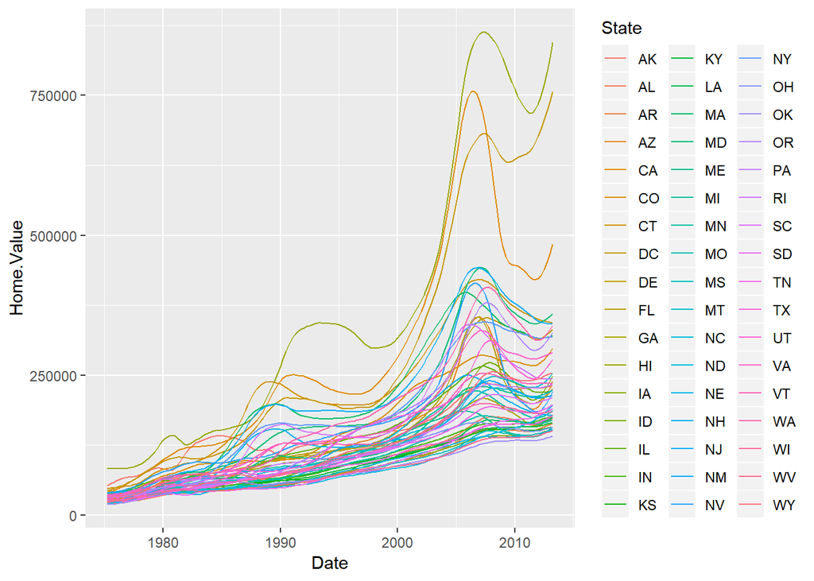

```r
ggplot(housing, aes(x = Date, y = Home.Value)) +
  geom_line(aes(color = State));
```

- There are two problems here-there are too many states to distinguish each one by color, and the lines obscure one another. `ggplot2` offers two functions for creating small multiples: - `facet_wrap()`: define subsets as the levels of a single grouping variable - `facet_grid()`: define subsets as the crossing of two grouping variables

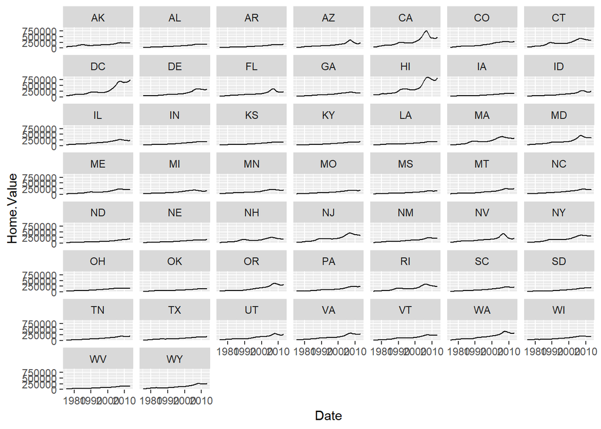

```r
ggplot(housing, aes(x = Date, y = Home.Value)) +
  geom_line()+
  facet_wrap(~State, ncol = 7);
```